# Visualization of Cell Type Annotations

Anthony Christidis, Andrew Ghazi, Smriti Chawla, Nitesh Turaga, Ludwig Geistlinger and Robert Gentleman

Core for Computational Biomedicine, Harvard Medical School

anthony-alexander_christidis@hms.harvard.edu

25 August 2024

#### Package

scDiagnostics 0.99.6

# 1 Introduction

This vignette demonstrates the use `plotCellTypeMDS`, `plotCellTypePCA`, `boxplotPCA` and `calculateDiscriminantSpace`, which are designed to help assess and compare cell types between query and reference datasets using Multidimensional Scaling (MDS) and Principal Component Analysis (PCA), and Fisher Discriminant Analysis (FDA) respectively.

This vignette also demonstrates how to visualize gene expression data from single-cell RNA sequencing (scRNA-seq) experiments using two functions: `plotGeneExpressionDimred` and `plotMarkerExpression.` These functions allow researchers to explore gene expression patterns across various dimensions and compare expression distributions between different datasets or cell types.

# 2 Preliminaries

In the context of the `scDiagnostics` package, this vignette illustrates how to evaluate cell type annotations using two distinct datasets:

- `reference_data`: This dataset consists of meticulously curated cell type annotations assigned by experts, providing a robust benchmark for assessing the quality of annotations. It serves as a standard reference to evaluate and detect anomalies or inconsistencies within the cell type annotations.
- `query_data`: This dataset includes annotations both from expert assessments and those generated by the `SingleR` package. By comparing these annotations, you can identify discrepancies between manual and automated results, thereby pinpointing potential inconsistencies or areas that may need further scrutiny.

```r
# Load library
library(scDiagnostics)

# Load datasets
data("reference_data")
data("query_data")

# Set seed for reproducibility
set.seed(0)
```

# 3 Visualization of Query vs. Reference Dataset

## 3.1 Plot Reference and Query Cell Types Using MDS

The `plotCellTypeMDS` function creates a scatter plot using Multidimensional Scaling (MDS) to visualize the similarity between cell types in query and reference datasets. This function generates a MDS plot that colors cells according to their types based on a dissimilarity matrix calculated from a specified gene set.

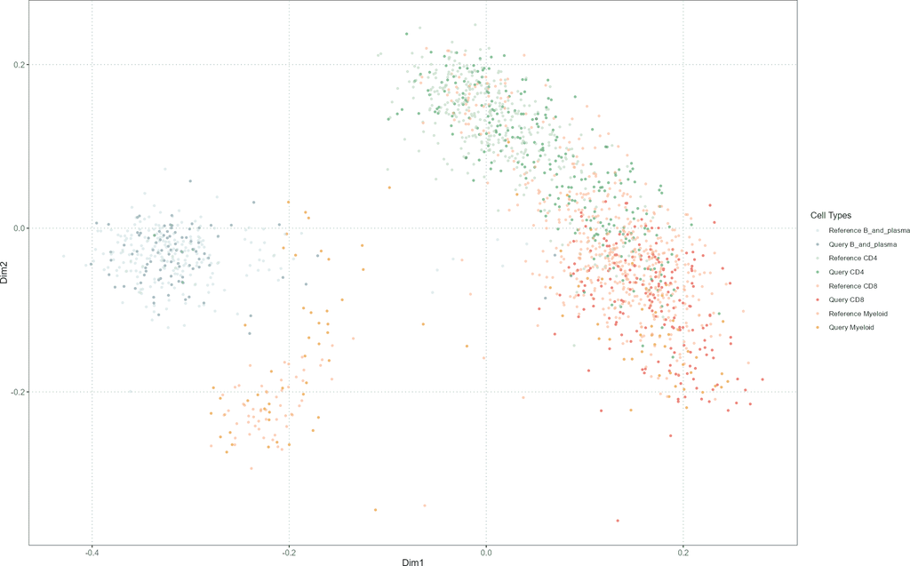

```r
# Generate the MDS scatter plot with cell type coloring
plotCellTypeMDS(query_data = query_data,
                reference_data = reference_data,
                cell_types = c("CD4", "CD8", "B_and_plasma", "Myeloid"),
                query_cell_type_col = "SingleR_annotation",
                ref_cell_type_col = "expert_annotation")
```

Notice how much more aligned the cell types are when using the expert annotation

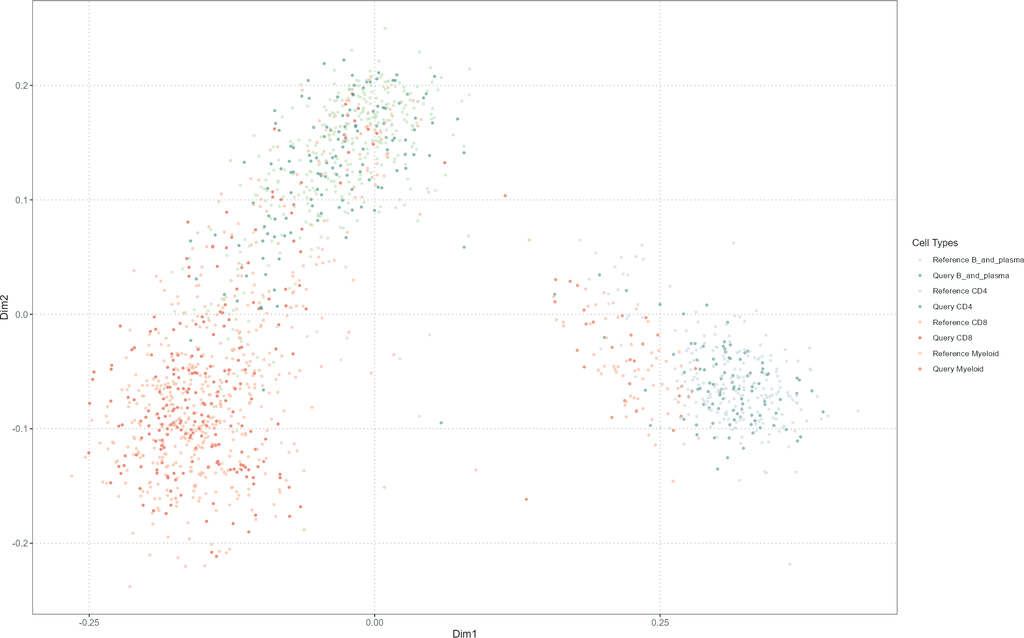

```r
# Plot the PCA data
plotCellTypeMDS(query_data = query_data,
                reference_data = reference_data,
                cell_types = c("CD4", "CD8", "B_and_plasma", "Myeloid"),
                query_cell_type_col = "expert_annotation",
                ref_cell_type_col = "expert_annotation")
```

## 3.2 Plot Principal Components for Different Cell Types

The `plotCellTypePCA` function projects the query dataset onto the PCA space of the reference dataset. It then plots specified principal components for different cell types, allowing comparison of PCA results between query and reference datasets.

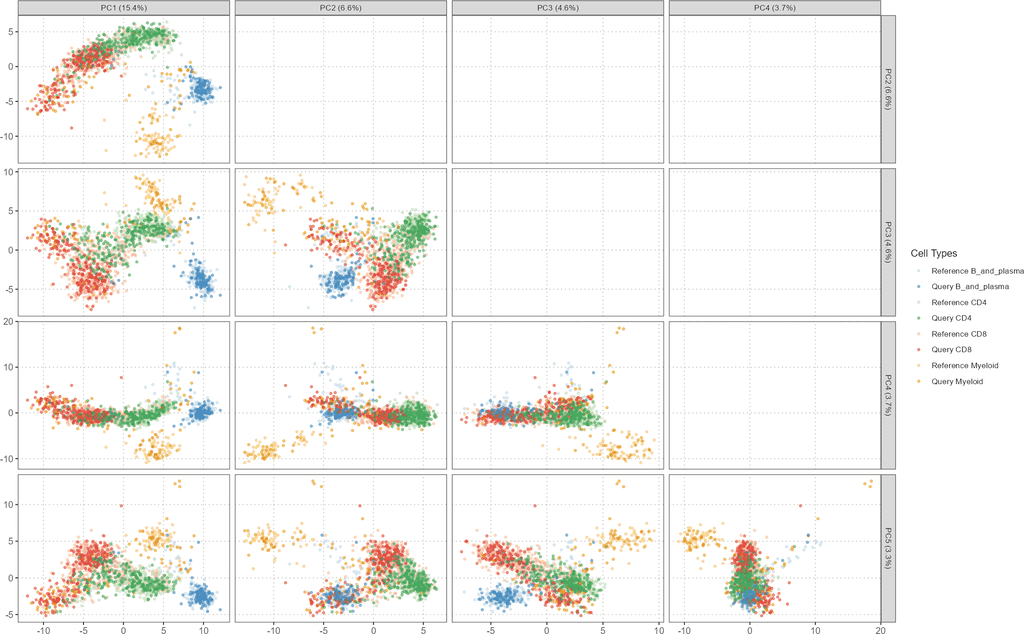

```r
# Generate the MDS scatter plot with cell type coloring
plotCellTypePCA(query_data = query_data,
                reference_data = reference_data,
                cell_types = c("CD4", "CD8", "B_and_plasma", "Myeloid"),
                query_cell_type_col = "SingleR_annotation",
                ref_cell_type_col = "expert_annotation",
                pc_subset = 1:5)
```

Here, `plotCellTypePCA` projects the query data into the PCA space of the reference data and plots the specified principal components. The `pc_subset` argument allows you to select which principal components to display.

## 3.3 Plot Principal Components as Boxplots

The `boxplotPCA` function provides a boxplot visualization of principal components for different cell types across query and reference datasets. This function helps in comparing the distributions of PCA scores for specified cell types and datasets.

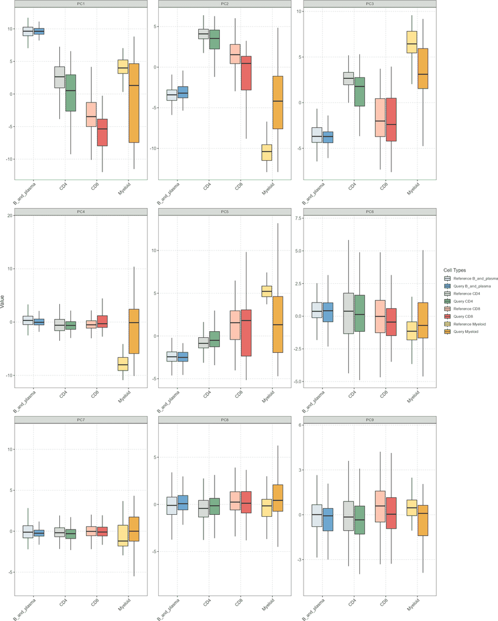

```r
# Plot the PCA data as boxplots
boxplotPCA(query_data = query_data,
           reference_data = reference_data,
           cell_types = c("CD4", "CD8", "B_and_plasma", "Myeloid"),
           query_cell_type_col = "SingleR_annotation",
           ref_cell_type_col = "expert_annotation",
           pc_subset = 1:9)
```

In this example, `boxplotPCA` generates boxplots for the specified principal components, showing the distribution of PCA scores for different cell types and datasets.

## 3.4 Project Query Data onto Discriminant Space of Reference Data

The `calculateDiscriminantSpace` function projects query single-cell RNA-seq data onto a discriminant space defined by reference data. This process involves using the reference data to identify key variables, compute discriminant vectors, and project both the reference and query data onto this space. The function then assesses the similarity between the projections of the query data and the reference data using cosine similarity and Mahalanobis distance.

## 3.5 Function Details

The function performs the following steps for each pairwise combination of cell types:

1. **Identify Important Variables**: Determine the most significant variables that distinguish the two cell types from the reference data.
2. **Compute Covariance Matrices**: Estimate the covariance matrices for each cell type using the Ledoit-Wolf shrinkage method.
3. **Construct Scatter Matrices**: Create within-class and between-class scatter matrices.
4. **Solve Eigenvalue Problem**: Solve the generalized eigenvalue problem to obtain discriminant vectors.
5. **Project Data**: Project both reference and query data onto the discriminant space.
6. **Assess Similarity**: Measure the similarity of the query data projections to the reference projections using cosine similarity and Mahalanobis distance.

### 3.5.1 Example Application

First, applying the function to the `SingleR` annotation.

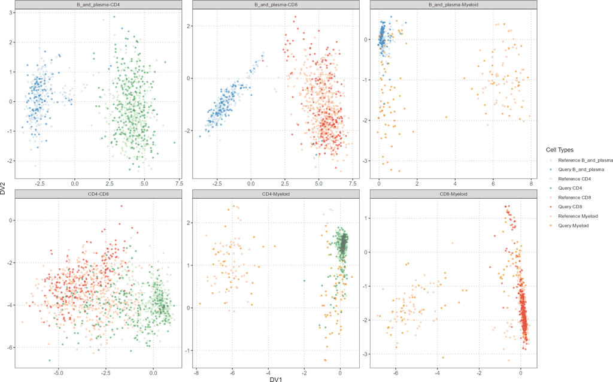

```r
# Compute important variables for all pairwise cell comparisons
disc_output <- calculateDiscriminantSpace(
  reference_data = reference_data,
  query_data = query_data,
  query_cell_type_col = "SingleR_annotation",
  ref_cell_type_col = "expert_annotation")

# Generate scatter and boxplot
plot(disc_output, plot_type = "scatterplot")
```

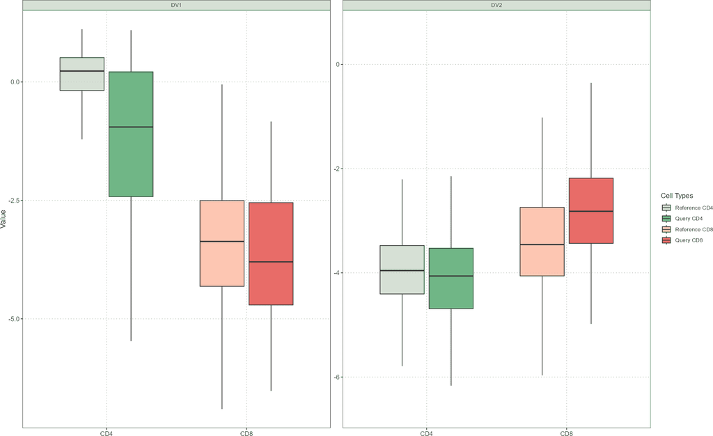

```r
plot(disc_output, cell_types = "CD4-CD8", plot_type = "boxplot")
```

```r
# Check comparison
table(Expert_Annotation = query_data$expert_annotation, SingleR = query_data$SingleR_annotation)
```

```
#>                  SingleR
#> Expert_Annotation B_and_plasma CD4 CD8 Myeloid
#>      B_and_plasma           94   0   0       4
#>      CD4                     0 126   0       4
#>      CD8                     2  90 127      12
#>      Myeloid                 0   0   0      30
```

### 3.5.2 Using Mahalanobis Distance for Anomaly Detection in Single-Cell RNA-Seq Data

We aim to evaluate whether a new batch of query cells fits well within established reference cell types or if there are cells exhibiting unusual characteristics. We will use the Mahalanobis distance calculated by the `calculateDiscriminantSpace` function to achieve this.

```r
# Perform discriminant analysis and projection
discriminant_results <- calculateDiscriminantSpace(
  reference_data = reference_data,
  query_data = query_data,
  ref_cell_type_col = "expert_annotation",
  query_cell_type_col = "SingleR_annotation",
  calculate_metrics = TRUE,  # Compute Mahalanobis distance and cosine similarity
  alpha = 0.01  # Significance level for Mahalanobis distance cutoff
)
```

You can extract and analyze the Mahalanobis distances of query cells relative to reference cell types. High Mahalanobis distances may indicate potential anomalies or novel cell states.

```r
# Extract Mahalanobis distances
mahalanobis_distances <- discriminant_results$`CD4-CD8`$query_mahalanobis_dist

# Identify anomalies based on a threshold
threshold <- discriminant_results$`CD4-CD8`$mahalanobis_crit  # Use the computed cutoff value
anomalies <- mahalanobis_distances[mahalanobis_distances > threshold]
```

You can now create visualizations to illustrate the distribution of Mahalanobis distances and highlight potential anomalies.

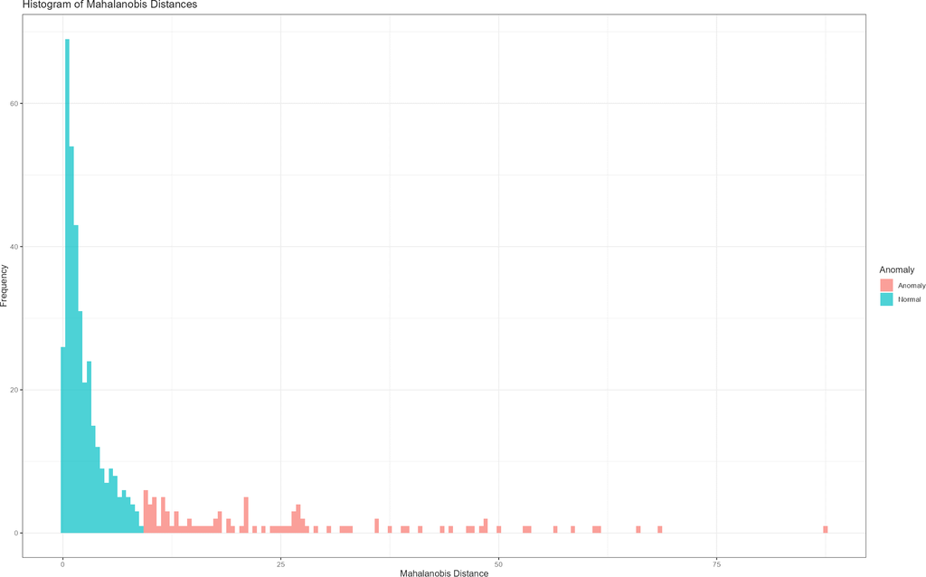

```r
# Load ggplot2 for visualization
library(ggplot2)

# Convert distances to a data frame
distances_df <- data.frame(Distance = mahalanobis_distances,
                           Anomaly = ifelse(mahalanobis_distances > threshold, "Anomaly", "Normal"))

# Plot histogram of Mahalanobis distances
ggplot(distances_df, aes(x = Distance, fill = Anomaly)) +
  geom_histogram(binwidth = 0.5, position = "identity", alpha = 0.7) +
  labs(title = "Histogram of Mahalanobis Distances",
       x = "Mahalanobis Distance",
       y = "Frequency") +
  theme_bw()
```

- **Low Mahalanobis Distances**: These query cells align well with the reference cell types, suggesting they are similar to the established cell types.
- **High Mahalanobis Distances**: Cells with high distances may represent outliers or novel, previously uncharacterized cell types. Further investigation may be needed to understand these anomalies.

# 4 Visualization of Marker Expressions

## 4.1 Visualizing Gene Expression in Reduced Dimensions

The `plotGeneExpressionDimred` function plots the expression of a specific gene on a dimensional reduction plot. This function is useful for exploring how gene expression varies across cells in the context of reduced dimensions, such as those derived from PCA, t-SNE, or UMAP. Each point on the plot represents a single cell, color-coded according to the expression level of the specified gene.

Let’s visualize the expression of the gene **VPREB3** on a PCA plot:

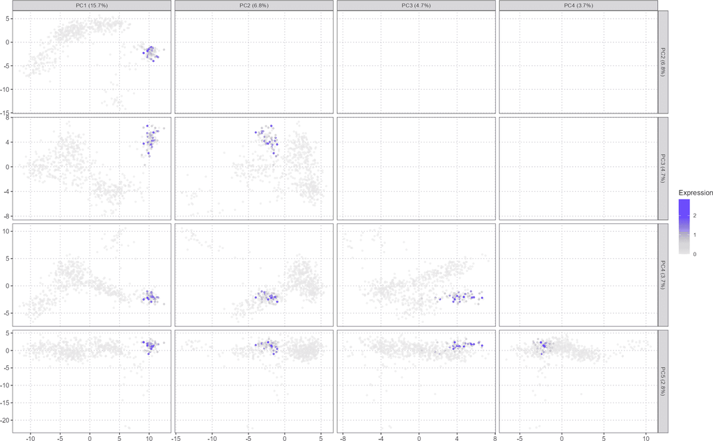

```r
# Visualize VPREB3 gene on a PCA plot
plotGeneExpressionDimred(se_object = query_data,
                         method = "PCA",
                         pc_subset = 1:5,
                         feature = "VPREB3")
```

In this example, we visualize the expression of the **VPREB3** gene on a PCA plot derived from the `query_data` dataset. The `method` argument specifies the dimensional reduction technique, which in this case is “PCA.” The `pc_subset` argument allows us to focus on specific principal components (PCs), here selecting the first five. The `feature` argument is the name of the gene we want to visualize.

When executed, this function generates a scatter plot with cells colored by their expression levels of **VPREB3**. The resulting plot can help identify clusters of cells with similar expression patterns or highlight how expression varies across the dataset.

You can also visualize gene expression using other dimensional reduction methods, such as t-SNE:

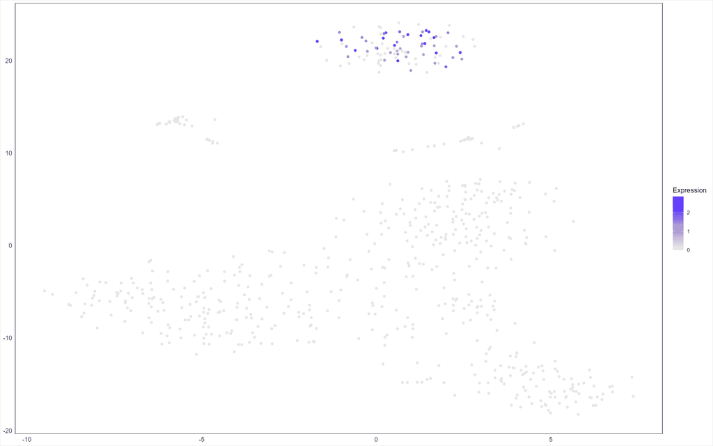

```r
# Visualize VPREB3 gene on a PCA plot
plotGeneExpressionDimred(se_object = query_data,
                         method = "TSNE",
                         pc_subset = 1:5,
                         feature = "VPREB3")
```

This command generates a t-SNE plot where cells are color-coded by their expression of the **VPREB3** gene. The t-SNE method often reveals more distinct clusters in data with complex relationships, which can be particularly useful for identifying subpopulations of cells with unique expression profiles.

## 4.2 Plotting Gene Expression Distribution

The `plotMarkerExpression` function compares the distribution of a specific gene’s expression across an overall dataset and within specific cell types. It generates density plots to visualize these distributions, providing a graphical means of assessing the similarity between reference and query datasets. The function also applies a z-rank normalization to make expression values comparable between datasets.

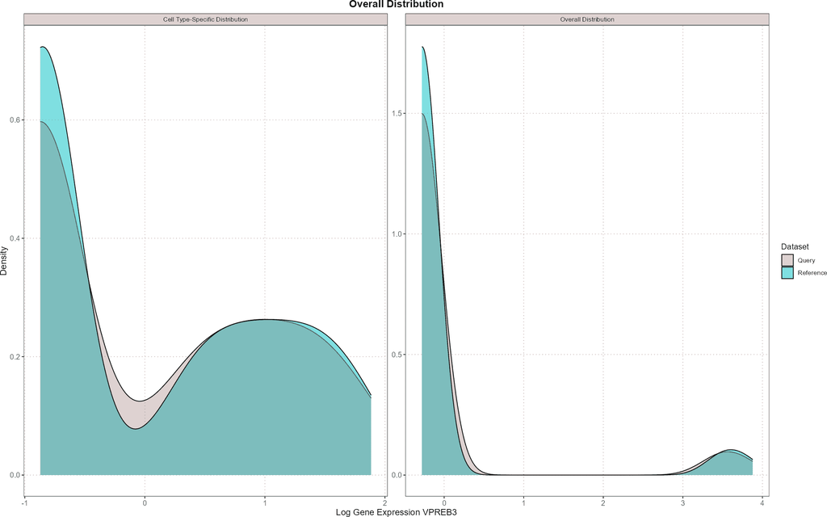

```r
plotMarkerExpression(
  reference_data = reference_data,
  query_data = query_data,
  ref_cell_type_col = "expert_annotation",
  query_cell_type_col = "SingleR_annotation",
  gene_name = "VPREB3",
  cell_type = "B_and_plasma"
)
```

In this example, the function compares the expression distribution of the **VPREB3** gene between the reference and query datasets. The `ref_cell_type_col` and `query_cell_type_col` arguments specify the columns in `colData` that identify the cell types in the reference and query datasets, respectively. The `cell_type` argument specifies the cell type of interest, and `gene_name` is the gene whose expression distribution we wish to compare.

When executed, this function generates two density plots: one showing the overall gene expression distribution across all cells and another focusing on the specified cell type. These plots help identify whether the gene’s expression levels are similar between the reference and query datasets, providing insight into dataset alignment.

# 5 Conclusion

Together, these functions provide a comprehensive toolkit for analyzing single-cell RNA-seq data, from initial exploratory data analysis to advanced comparison and projection methods. By integrating these tools into your workflow, you can gain deeper insights into cell type annotations, improve data quality, and enhance the robustness of your single-cell analyses.